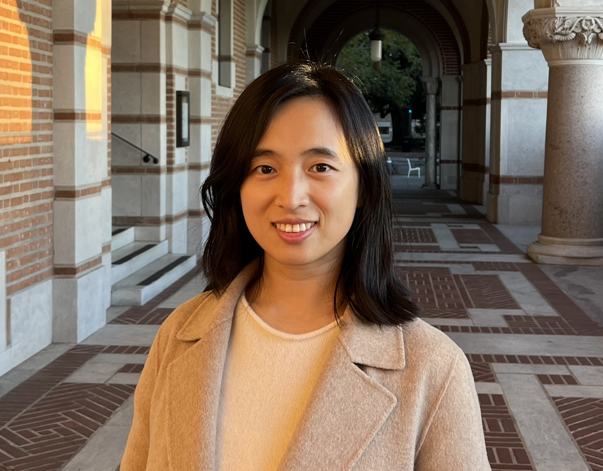

# About

I’m an Assistant Professor in the [Department of Communication at the University at Buffalo (SUNY-Buffalo)](http://www.buffalo.edu/cas/communication.html). I received my Ph.D. in Communication from the [School of Journalism & Mass Communication at the University of Wisconsin-Madison](https://journalism.wisc.edu).

# Research

My research is driven by a core question: How do certain issues and actors capture attention and wield influence in an era of information overload? I approach this question by considering both the technological/structural and user dimensions of media, including social media and AI.

Three interlinked questions guide my work:

- How does attention coalesce around specific issues and actors on social media, and how does information flow across the broader media ecosystem?
- How do people make sense of communication technologies, and what shapes their trust or distrust of them?
- What are the implications of the current media environment for politics and society?

Methodologically, my work is primarily computational. Typical projects involve:

- Collecting large-scale data from social media platforms (e.g., Twitter/X, YouTube, Truth Social)
- Conducting automated text analysis using machine learning and large language models
- Detecting communities through network analysis
- Modeling temporal dynamics with time series methods

In addition to using existing techniques, I collaborate with colleagues from other disciplines to develop methods tailored to questions in communication research.

# Teaching

I find genuine joy in helping students build their skills and knowledge. At UB, I have taught undergraduate and graduate courses on:

- Social media and society
- Communication theory
- Research methods
- Introduction to mass communication

Student feedback and notes of appreciation continually motivate me to refine my teaching and experiment with new ways of integrating data, theory, and real-world cases in the classroom.

# Research Lab

In the [Communication and Emerging Media (CEM) lab](https://cemlab.github.io/), I collaborate with graduate and undergraduate students at UB and partner institution on ongoing research projects, while also supporting them in developing and launching their own independent work. Recent publications, current projects, and information about lab members and alumni are available on the CEM Lab website.

# Miscellaneous

Outside of research and teaching, I spend much of my time with my two kids. I used to be a fan of classical and rock music; these days, I am more likely to listen to podcasts during my commute. Recommendations are always welcome.